# Report of index aggregation

Luna Zhang, AbacusBio

2022-06-21

# Disclaimer

This report is generated from the **Plant Index Aggregation App**. You may notice some `NULL` or `NA` in the report. It means the corresponding analysis was skipped when the app was used.

# Background

The objective of this analysis is to create aggregated indexes that can represent clusters of numeric original indexes. The report contains the information of the original and aggregated indexes, the process of cluster forming, and the evaluation of the performance of the aggregated indexes.

# Input

## Files

| Table | File |
| --- | --- |
| Breeding value | demo |
| Economic value | demo |
| Economic value weight | demo |

# Filters

Missing EBV set to 0:, FALSE

Table filters

| Table | column | level |
| --- | --- | --- |
| Breeding value |  |  |
| Economic value |  |  |

# Summary statistics

## Breeding value

Breeding value summary statistics

| variable | mean | sd | min | max | n_missing | n | n_obs |
| --- | --- | --- | --- | --- | --- | --- | --- |
| GLEAFSPOT | -0.09 | 0.47 | -1.46 | 1.29 | 450 | 949 | 499 |
| ANTHRAC | -0.83 | 0.82 | -3.63 | 1.41 | 450 | 949 | 499 |
| GOSSWILT | -0.09 | 0.89 | -2.69 | 2.98 | 449 | 949 | 500 |
| FUSARIUM | -0.02 | 1.03 | -3.12 | 3.76 | 449 | 949 | 500 |
| GIBBERELLA | 0.44 | 0.86 | -1.64 | 2.93 | 449 | 949 | 500 |
| NLEAFBLIGHT | 0.02 | 0.67 | -2.06 | 1.89 | 449 | 949 | 500 |
| BROWNRUST | -0.42 | 1.00 | -3.79 | 2.84 | 449 | 949 | 500 |
| TARSPOT | -0.01 | 0.11 | -0.35 | 0.33 | 449 | 949 | 500 |
| YIELD | 4.42 | 8.51 | -20.22 | 32.24 | 449 | 949 | 500 |
| GREENSNAP | -0.41 | 6.64 | -18.31 | 16.28 | 449 | 949 | 500 |
| ROOTLODGE | -0.10 | 2.55 | -7.48 | 7.32 | 449 | 949 | 500 |
| STALKLODGE | -0.06 | 1.27 | -4.09 | 3.86 | 449 | 949 | 500 |
| TESTWT | 0.00 | 0.98 | -2.88 | 3.63 | 449 | 949 | 500 |
| MOIST | 0.24 | 1.79 | -6.24 | 6.45 | 449 | 949 | 500 |

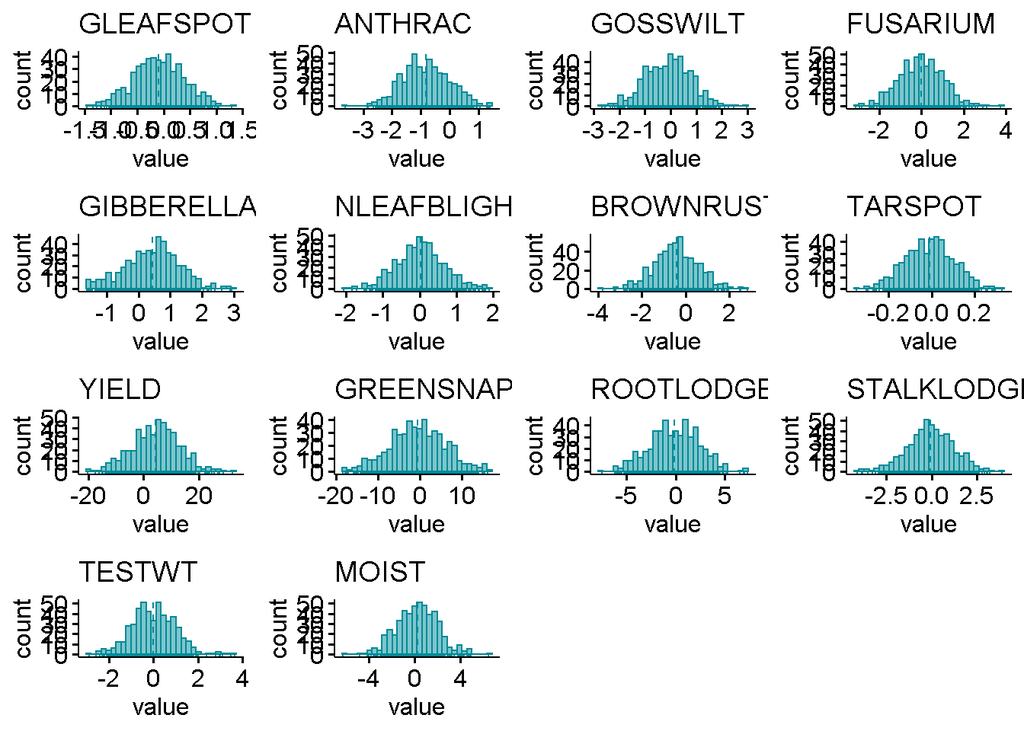

### Classification variable

#### Distribution

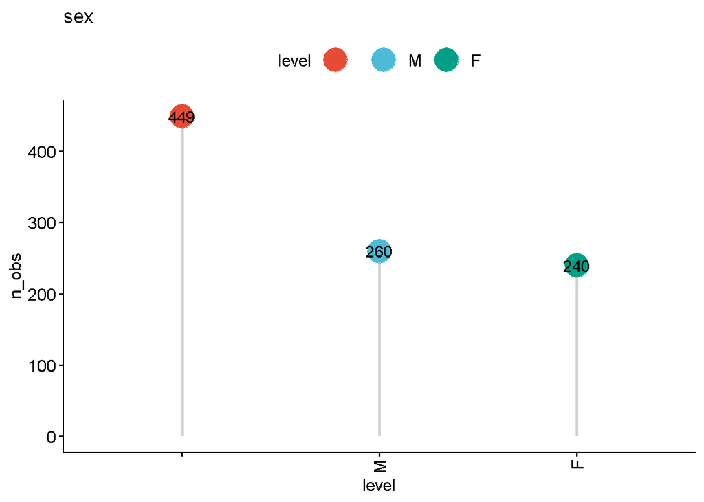

#### Full table

classification variables summary statistics

| variable | level | n | n_missing | n_obs | prop |
| --- | --- | --- | --- | --- | --- |
| sex |  | 449 | 0 | 449 | 0.47 |
| sex | F | 240 | 0 | 240 | 0.25 |
| sex | M | 260 | 0 | 260 | 0.27 |

## Economic value

Economic value summary statistics

| variable | mean | sd | min | max | n_missing | n | n_obs |
| --- | --- | --- | --- | --- | --- | --- | --- |
| YIELD | 0.11 | 0.30 | 0.00 | 1.38 | 0 | 727 | 727 |
| GREENSNAP | -1.64 | 1.54 | -5.60 | 0.00 | 0 | 727 | 727 |
| EMERG | 1.53 | 2.41 | 0.00 | 6.15 | 0 | 727 | 727 |
| GLEAFSPOT | -1.08 | 2.55 | -11.46 | 0.00 | 0 | 727 | 727 |
| ANTHRAC | -0.08 | 0.23 | -1.04 | 0.00 | 0 | 727 | 727 |
| GOSSWILT | -2.17 | 4.58 | -21.50 | 0.00 | 0 | 727 | 727 |
| FUSARIUM | -0.16 | 0.25 | -0.99 | 0.00 | 0 | 727 | 727 |
| GIBBERELLA | -0.45 | 0.80 | -3.40 | 0.00 | 0 | 727 | 727 |
| NLEAFBLIGHT | -1.00 | 2.21 | -9.69 | 0.00 | 0 | 727 | 727 |
| BROWNRUST | -1.47 | 3.70 | -17.86 | 0.00 | 0 | 727 | 727 |
| TARSPOT | -1.29 | 2.26 | -8.32 | 0.00 | 0 | 727 | 727 |

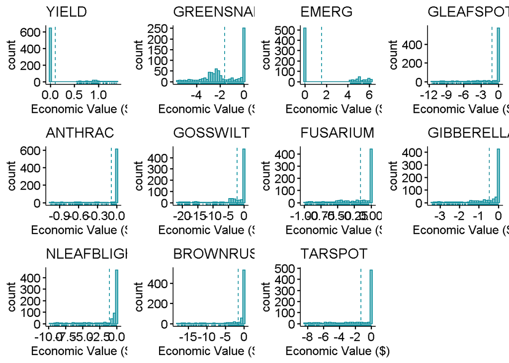

### Classification variable

#### Distribution

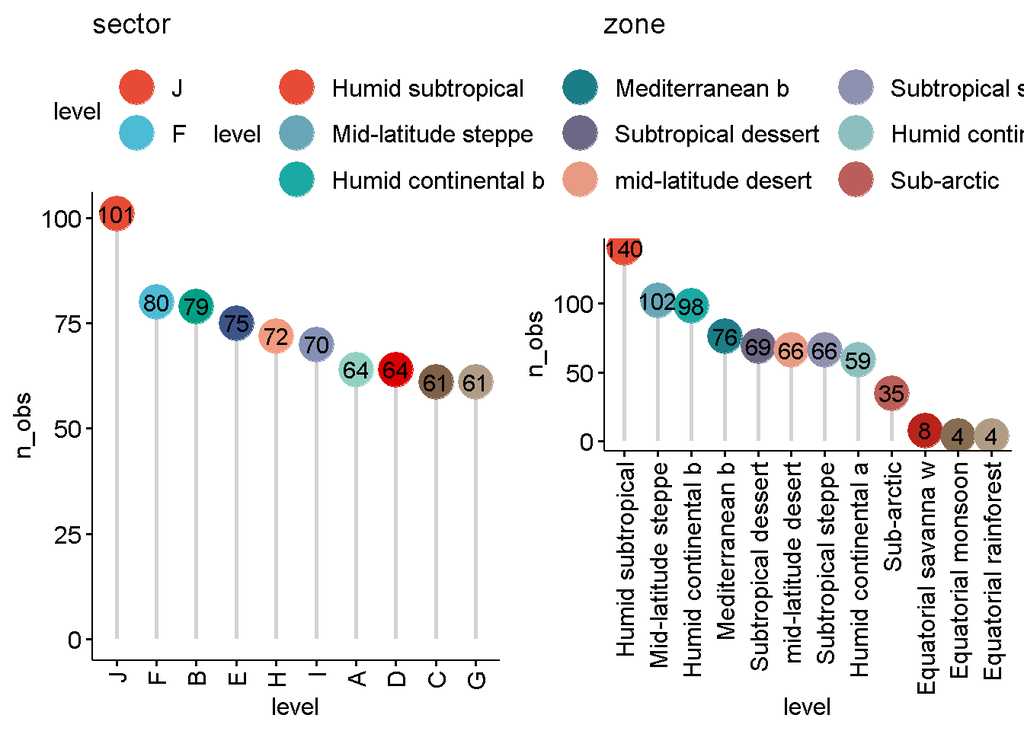

#### Full table

classification variables summary statistics

| variable | level | n | n_missing | n_obs | prop |
| --- | --- | --- | --- | --- | --- |
| sector | A | 64 | 0 | 64 | 0.09 |
| sector | B | 79 | 0 | 79 | 0.11 |
| sector | C | 61 | 0 | 61 | 0.08 |
| sector | D | 64 | 0 | 64 | 0.09 |
| sector | E | 75 | 0 | 75 | 0.10 |
| sector | F | 80 | 0 | 80 | 0.11 |
| sector | G | 61 | 0 | 61 | 0.08 |
| sector | H | 72 | 0 | 72 | 0.10 |
| sector | I | 70 | 0 | 70 | 0.10 |
| sector | J | 101 | 0 | 101 | 0.14 |
| zone | Equatorial monsoon | 4 | 0 | 4 | 0.01 |
| zone | Equatorial rainforest | 4 | 0 | 4 | 0.01 |
| zone | Equatorial savanna w | 8 | 0 | 8 | 0.01 |
| zone | Humid continental a | 59 | 0 | 59 | 0.08 |
| zone | Humid continental b | 98 | 0 | 98 | 0.13 |
| zone | Humid subtropical | 140 | 0 | 140 | 0.19 |
| zone | Mediterranean b | 76 | 0 | 76 | 0.10 |
| zone | mid-latitude desert | 66 | 0 | 66 | 0.09 |
| zone | Mid-latitude steppe | 102 | 0 | 102 | 0.14 |
| zone | Sub-arctic | 35 | 0 | 35 | 0.05 |
| zone | Subtropical dessert | 69 | 0 | 69 | 0.09 |
| zone | Subtropical steppe | 66 | 0 | 66 | 0.09 |

## Original indexes

You have 499 individuals and 727 original indexes.  
Individuals with missing breeding value are removed.

### Full table

Original index summary statistics

| variable | mean | sd | min | max |
| --- | --- | --- | --- | --- |
| index_1 | 0.88 | 13.72 | -33.69 | 37.67 |
| index_10 | -0.04 | 0.18 | -0.71 | 0.44 |
| index_11 | 0.33 | 15.56 | -39.34 | 42.78 |
| index_12 | -0.11 | 3.74 | -8.97 | 10.87 |
| index_13 | 0.00 | 0.07 | -0.21 | 0.23 |
| index_14 | 0.55 | 11.78 | -38.25 | 32.00 |
| index_15 | 2.76 | 8.73 | -20.60 | 30.27 |
| index_16 | 4.48 | 8.58 | -20.79 | 32.45 |
| index_17 | 9.28 | 27.84 | -65.32 | 92.93 |
| index_18 | 6.04 | 19.84 | -46.16 | 69.69 |
| index_19 | 5.53 | 18.58 | -51.91 | 60.85 |
| index_100 | 2.59 | 22.21 | -68.46 | 74.75 |
| index_101 | 1.03 | 16.95 | -41.28 | 46.70 |
| index_102 | 1.67 | 6.23 | -17.49 | 18.28 |
| index_103 | 0.10 | 0.96 | -3.25 | 2.89 |
| index_104 | 1.48 | 20.90 | -51.38 | 56.62 |
| index_105 | 0.75 | 21.72 | -53.20 | 58.66 |
| index_106 | 0.60 | 1.43 | -4.02 | 5.32 |
| index_107 | 0.34 | 2.26 | -5.58 | 8.50 |
| index_108 | 1.43 | 18.50 | -45.33 | 55.14 |
| index_109 | 1.59 | 30.53 | -74.68 | 83.26 |
| index_110 | 0.70 | 4.91 | -15.65 | 15.58 |
| index_111 | 4.47 | 8.77 | -21.88 | 28.69 |
| index_112 | 3.30 | 8.53 | -21.51 | 28.20 |
| index_113 | 7.36 | 36.63 | -83.84 | 109.84 |
| index_114 | 8.07 | 22.98 | -55.75 | 77.22 |
| index_115 | 1.82 | 19.12 | -56.01 | 62.45 |
| index_116 | 0.58 | 18.28 | -45.34 | 50.32 |
| index_117 | 6.71 | 20.06 | -46.97 | 67.65 |
| index_118 | 0.59 | 0.55 | -1.11 | 2.55 |

[output cut: 697 more lines]

# Clustering analysis

## Clusters

The *Index by individual* matrix is used as the input. Hierarchical clustering with agglomeration algorithm is used to compute the clustering. $k = 5$ clusters was chosen in the end.

### Result

```
## [1] "NA"
```

The full table is downloaded separately.

### Parameter Tuning

There are three ways to determine the best k:

#### by merging steps:

The best k is 3 at the largest height change of 273.987232.

#### by largest total within-cluster sum of squares drop:

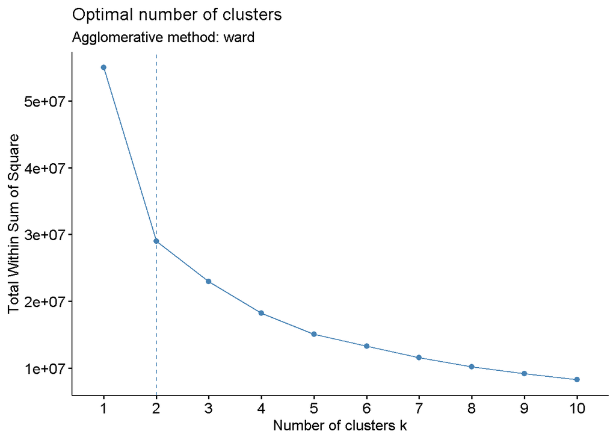

#### by largest mean within-cluster silhouette value

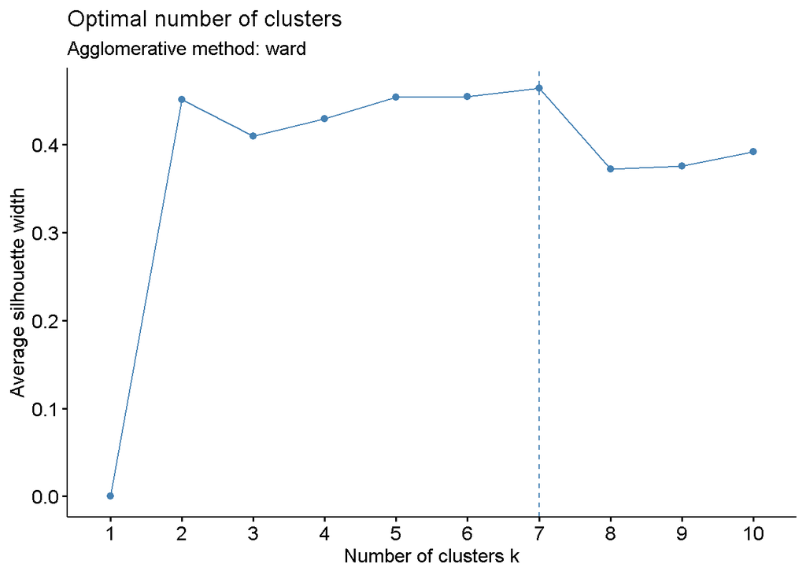

## Summary statistics

### Within Cluster correlation distribution

Within Cluster correlation

| cluster | n_corr | mean | median | sd | min | max | n_corr_missing | n_index |
| --- | --- | --- | --- | --- | --- | --- | --- | --- |
| 1 | 73920 | 0.955 | 0.970 | 0.049 | 0.648 | 1 | 0 | 385 |
| 2 | 8778 | 0.239 | 0.181 | 0.336 | -0.796 | 1 | 777 | 133 |
| 3 | 1035 | 0.737 | 0.759 | 0.181 | 0.018 | 1 | 0 | 46 |
| 4 | 2850 | 0.708 | 0.757 | 0.237 | 0.163 | 1 | 0 | 76 |
| 5 | 3741 | 0.828 | 0.863 | 0.142 | 0.232 | 1 | 0 | 87 |

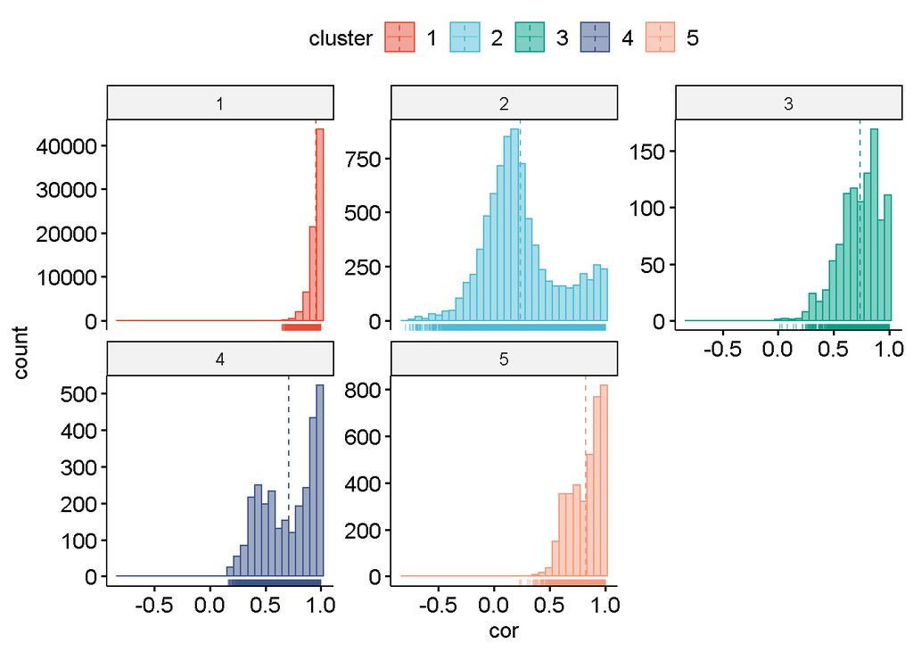

## Diagnosis

Below is the *index correlation* matrix heatmap.

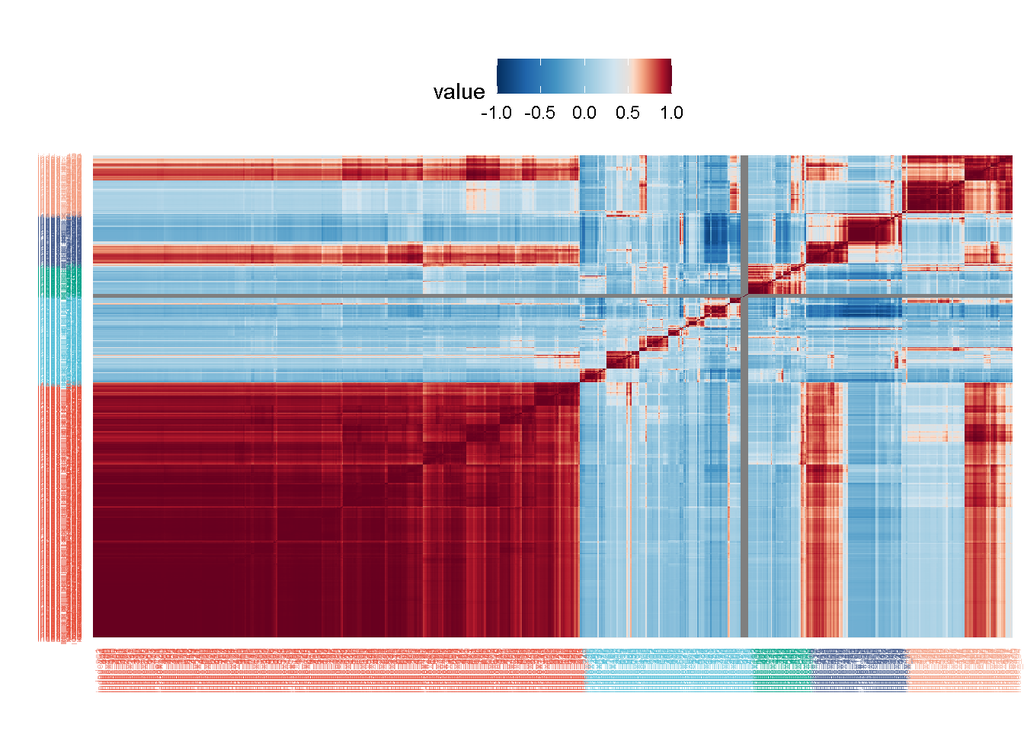

The full correlation matrix can be downloaded separately.

# Aggregated index

## Index weight

The *weight* was used to weigh original indexes within their cluster.

### Sneak peek

|  | Index | cluster | weight |
| --- | --- | --- | --- |
| 1 | index_1 | 1 | 0.0017822 |
| 262 | index_262 | 1 | 0.0035383 |
| 584 | index_584 | 1 | 0.0035383 |
| 646 | index_646 | 1 | 0.0032081 |
| 429 | index_429 | 1 | 0.0017822 |
| 128 | index_128 | 1 | 0.0016466 |

### full table

|  | Index | cluster | weight |
| --- | --- | --- | --- |
| 1 | index_1 | 1 | 0.0017822 |
| 262 | index_262 | 1 | 0.0035383 |
| 584 | index_584 | 1 | 0.0035383 |
| 646 | index_646 | 1 | 0.0032081 |
| 429 | index_429 | 1 | 0.0017822 |
| 128 | index_128 | 1 | 0.0016466 |
| 409 | index_409 | 1 | 0.0021414 |
| 20 | index_20 | 1 | 0.0045386 |
| 550 | index_550 | 1 | 0.0022669 |
| 476 | index_476 | 1 | 0.0017822 |
| 173 | index_173 | 1 | 0.0021414 |
| 230 | index_230 | 1 | 0.0026659 |
| 330 | index_330 | 1 | 0.0017822 |
| 331 | index_331 | 1 | 0.0009833 |
| 481 | index_481 | 1 | 0.0045386 |
| 664 | index_664 | 1 | 0.0016466 |
| 651 | index_651 | 1 | 0.0021414 |
| 380 | index_380 | 1 | 0.0021414 |
| 341 | index_341 | 1 | 0.0045386 |
| 466 | index_466 | 1 | 0.0022669 |
| 297 | index_297 | 1 | 0.0009833 |
| 276 | index_276 | 1 | 0.0022669 |
| 665 | index_665 | 1 | 0.0026659 |
| 387 | index_387 | 1 | 0.0017822 |
| 73 | index_73 | 1 | 0.0022669 |
| 151 | index_151 | 1 | 0.0032081 |
| 241 | index_241 | 1 | 0.0009833 |
| 417 | index_417 | 1 | 0.0032081 |
| 130 | index_130 | 1 | 0.0040356 |
| 343 | index_343 | 1 | 0.0017822 |

[output cut: 697 more lines]

## Aggregated index economic values

New economic values

| Index | cluster | YIELD | GREENSNAP | EMERG | GLEAFSPOT | ANTHRAC | GOSSWILT | FUSARIUM | GIBBERELLA | NLEAFBLIGHT | BROWNRUST | TARSPOT |
| --- | --- | --- | --- | --- | --- | --- | --- | --- | --- | --- | --- | --- |
| new_index_1 | 1 | 0.083 | -2.732 | 1.568 | -1.061 | -0.086 | -1.089 | -0.172 | -0.455 | -0.960 | -0.365 | -1.385 |
| new_index_2 | 2 | 0.202 | -0.038 | 1.686 | -1.474 | -0.134 | -0.493 | -0.173 | -0.663 | -0.526 | -0.120 | -1.308 |
| new_index_3 | 3 | 0.000 | -0.060 | 2.112 | -0.551 | -0.072 | -0.612 | -0.144 | -0.417 | -4.488 | -0.406 | -1.216 |
| new_index_4 | 4 | 0.125 | -0.953 | 1.679 | -0.920 | -0.028 | -1.182 | -0.098 | -0.277 | -0.720 | -10.781 | -1.250 |
| new_index_5 | 5 | 0.082 | -0.817 | 1.302 | -1.006 | -0.101 | -11.049 | -0.133 | -0.330 | -0.528 | -1.119 | -1.160 |
| avg_index | NA | 0.106 | -1.638 | 1.534 | -1.077 | -0.084 | -2.173 | -0.157 | -0.450 | -1.005 | -1.468 | -1.287 |

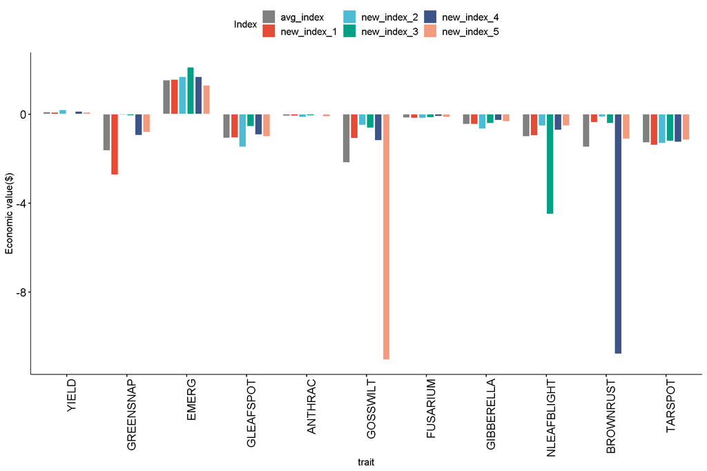

## Aggregated index relative economic weight (RW)

$RW = EV \times SD(EBV)$

New relative economic weight

| Index | cluster | YIELD | GREENSNAP | GLEAFSPOT | ANTHRAC | GOSSWILT | FUSARIUM | GIBBERELLA | NLEAFBLIGHT | BROWNRUST | TARSPOT |
| --- | --- | --- | --- | --- | --- | --- | --- | --- | --- | --- | --- |
| new_index_1 | 1 | 0.709 | -18.129 | -0.500 | -0.070 | -0.968 | -0.177 | -0.392 | -0.638 | -0.365 | -0.156 |
| new_index_2 | 2 | 1.720 | -0.254 | -0.696 | -0.109 | -0.438 | -0.178 | -0.571 | -0.350 | -0.120 | -0.147 |
| new_index_3 | 3 | 0.000 | -0.399 | -0.260 | -0.059 | -0.544 | -0.149 | -0.359 | -2.986 | -0.406 | -0.137 |
| new_index_4 | 4 | 1.065 | -6.327 | -0.434 | -0.023 | -1.050 | -0.101 | -0.238 | -0.479 | -10.778 | -0.141 |
| new_index_5 | 5 | 0.698 | -5.422 | -0.475 | -0.082 | -9.815 | -0.137 | -0.284 | -0.351 | -1.119 | -0.131 |
| avg_index | NA | 0.898 | -10.870 | -0.508 | -0.068 | -1.931 | -0.161 | -0.388 | -0.668 | -1.468 | -0.145 |

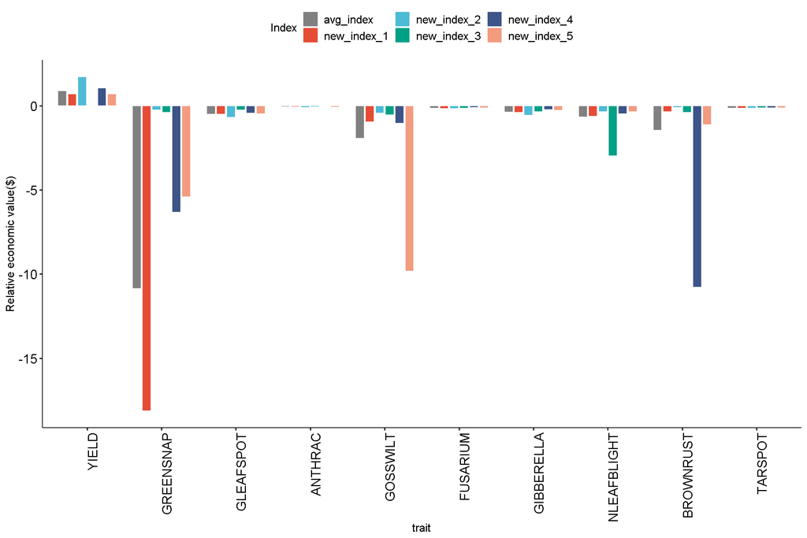

# Aggregated index diagnosis

This is to investigate the relationships between original and aggregated indexes, and across aggregated indexes, with or without comparison with a benchmark index, to evaluate how well aggregated indexes represent their own cluster.

## Correlation

The ideal outcome is that the majority of the correlations of original indexes with their corresonding aggregated indexes are higher than the correlations of original indexes with a benchmark index.

### Distribution of correlations between within-cluster indexes and their aggregated index

#### All aggregated index and the benchmark index

Below is the sorted correlations between within-cluster original indexes and their aggregated indexes (coloured dots) vs. those between original indexes and the benchmark index: *average*.

##### plot

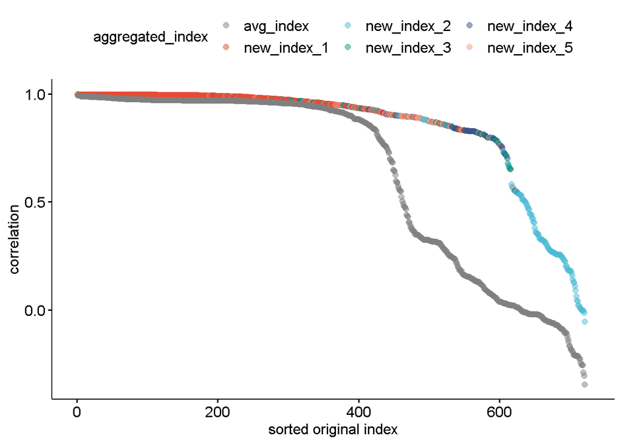

##### full table

Correlation between original and aggregated indexes

| Index | aggregated_index | correlation | id |
| --- | --- | --- | --- |
| index_520 | new_index_1 | 0.999 | 1 |
| index_37 | new_index_1 | 0.998 | 2 |
| index_555 | new_index_1 | 0.998 | 3 |
| index_224 | new_index_1 | 0.998 | 4 |
| index_444 | new_index_1 | 0.998 | 5 |
| index_281 | new_index_1 | 0.998 | 6 |
| index_91 | new_index_1 | 0.998 | 7 |
| index_389 | new_index_1 | 0.998 | 8 |
| index_288 | new_index_1 | 0.998 | 9 |
| index_26 | new_index_1 | 0.998 | 10 |
| index_222 | new_index_1 | 0.998 | 11 |
| index_244 | new_index_1 | 0.998 | 12 |
| index_398 | new_index_1 | 0.998 | 13 |
| index_691 | new_index_1 | 0.997 | 14 |
| index_180 | new_index_1 | 0.997 | 15 |
| index_487 | new_index_1 | 0.997 | 16 |
| index_122 | new_index_1 | 0.997 | 17 |
| index_363 | new_index_1 | 0.997 | 18 |
| index_452 | new_index_1 | 0.997 | 19 |
| index_567 | new_index_1 | 0.997 | 20 |
| index_373 | new_index_1 | 0.997 | 21 |
| index_722 | new_index_1 | 0.997 | 22 |
| index_294 | new_index_1 | 0.997 | 23 |
| index_395 | new_index_1 | 0.997 | 24 |
| index_396 | new_index_1 | 0.997 | 25 |
| index_339 | new_index_1 | 0.997 | 26 |
| index_139 | new_index_1 | 0.997 | 27 |
| index_688 | new_index_1 | 0.997 | 28 |
| index_519 | new_index_1 | 0.997 | 29 |
| index_352 | new_index_1 | 0.997 | 30 |

[output cut: 1424 more lines]

#### Selected indexes

Below is the sorted Distribution of correlations among aggregated indexes and cluster 4 indexes

##### plot

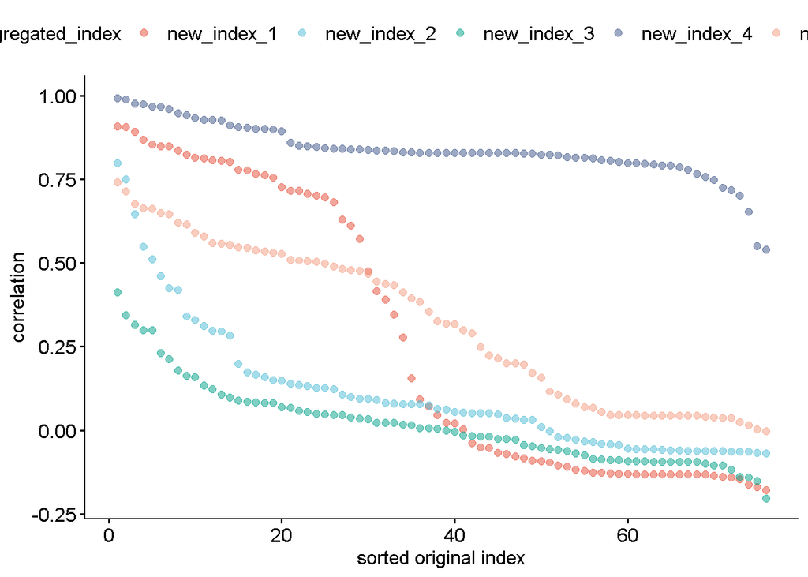

##### full table

Correlation between selected original and aggregated indexes

|  | new_index_1 | new_index_2 | new_index_3 | new_index_4 | new_index_5 | index_15 | index_298 | index_17 | index_117 | index_126 | index_641 | index_215 | index_264 | index_463 | index_715 | index_644 | index_375 | index_393 | index_506 | index_18 | index_486 | index_680 | index_186 | index_378 | index_540 | index_682 | index_60 | index_114 | index_718 | … |
| --- | --- | --- | --- | --- | --- | --- | --- | --- | --- | --- | --- | --- | --- | --- | --- | --- | --- | --- | --- | --- | --- | --- | --- | --- | --- | --- | --- | --- | --- | --- |
| new_index_1 | 1.000 | 0.207 | 0.151 | 0.437 | 0.608 | 0.803 | 0.893 | 0.779 | 0.766 | 0.716 | 0.812 | 0.849 | 0.848 | 0.869 | 0.835 | 0.906 | 0.823 | 0.854 | 0.909 | 0.805 | 0.808 | 0.702 | 0.716 | 0.727 | 0.815 | 0.695 | 0.778 | 0.706 | 0.681 | … |
| new_index_2 | 0.207 | 1.000 | 0.158 | 0.149 | 0.383 | 0.330 | 0.312 | 0.132 | 0.123 | 0.173 | 0.199 | 0.095 | 0.095 | 0.100 | 0.107 | 0.126 | 0.148 | 0.136 | 0.166 | 0.150 | 0.090 | 0.079 | 0.340 | 0.283 | 0.424 | 0.549 | 0.511 | 0.075 | 0.063 | … |
| new_index_3 | 0.151 | 0.158 | 1.000 | 0.030 | 0.272 | 0.159 | 0.180 | 0.068 | 0.069 | 0.089 | 0.107 | 0.045 | 0.050 | 0.055 | 0.059 | 0.163 | 0.122 | 0.086 | 0.135 | 0.299 | 0.231 | 0.300 | -0.005 | 0.000 | 0.023 | -0.019 | 0.039 | 0.022 | 0.015 | … |
| new_index_4 | 0.437 | 0.149 | 0.030 | 1.000 | 0.434 | 0.795 | 0.702 | 0.899 | 0.905 | 0.926 | 0.851 | 0.828 | 0.831 | 0.808 | 0.844 | 0.757 | 0.859 | 0.835 | 0.748 | 0.840 | 0.849 | 0.893 | 0.902 | 0.912 | 0.791 | 0.787 | 0.801 | 0.932 | 0.943 | … |
| new_index_5 | 0.608 | 0.383 | 0.272 | 0.434 | 1.000 | 0.665 | 0.741 | 0.590 | 0.616 | 0.650 | 0.554 | 0.534 | 0.537 | 0.545 | 0.528 | 0.560 | 0.661 | 0.621 | 0.715 | 0.676 | 0.531 | 0.489 | 0.507 | 0.509 | 0.547 | 0.505 | 0.558 | 0.479 | 0.468 | … |
| index_15 | 0.803 | 0.330 | 0.159 | 0.795 | 0.665 | 1.000 | 0.979 | 0.933 | 0.921 | 0.939 | 0.972 | 0.911 | 0.912 | 0.912 | 0.915 | 0.908 | 0.933 | 0.929 | 0.923 | 0.916 | 0.902 | 0.869 | 0.878 | 0.889 | 0.876 | 0.806 | 0.927 | 0.889 | 0.879 | … |
| index_298 | 0.893 | 0.312 | 0.180 | 0.702 | 0.741 | 0.979 | 1.000 | 0.914 | 0.904 | 0.908 | 0.948 | 0.912 | 0.912 | 0.919 | 0.908 | 0.928 | 0.934 | 0.936 | 0.960 | 0.919 | 0.892 | 0.834 | 0.841 | 0.853 | 0.871 | 0.781 | 0.900 | 0.849 | 0.833 | … |
| index_17 | 0.779 | 0.132 | 0.068 | 0.899 | 0.590 | 0.933 | 0.914 | 1.000 | 0.998 | 0.989 | 0.979 | 0.985 | 0.986 | 0.980 | 0.988 | 0.958 | 0.993 | 0.990 | 0.957 | 0.967 | 0.975 | 0.953 | 0.950 | 0.967 | 0.914 | 0.842 | 0.902 | 0.989 | 0.984 | … |
| index_117 | 0.766 | 0.123 | 0.069 | 0.905 | 0.616 | 0.921 | 0.904 | 0.998 | 1.000 | 0.991 | 0.967 | 0.978 | 0.980 | 0.973 | 0.981 | 0.949 | 0.994 | 0.988 | 0.957 | 0.970 | 0.970 | 0.950 | 0.946 | 0.963 | 0.907 | 0.837 | 0.888 | 0.986 | 0.982 | … |
| index_126 | 0.716 | 0.173 | 0.089 | 0.926 | 0.650 | 0.939 | 0.908 | 0.989 | 0.991 | 1.000 | 0.964 | 0.949 | 0.951 | 0.942 | 0.954 | 0.915 | 0.981 | 0.967 | 0.935 | 0.960 | 0.947 | 0.939 | 0.934 | 0.951 | 0.884 | 0.825 | 0.890 | 0.973 | 0.972 | … |
| index_641 | 0.812 | 0.199 | 0.107 | 0.851 | 0.554 | 0.972 | 0.948 | 0.979 | 0.967 | 0.964 | 1.000 | 0.974 | 0.974 | 0.972 | 0.975 | 0.961 | 0.968 | 0.974 | 0.944 | 0.946 | 0.964 | 0.935 | 0.928 | 0.944 | 0.909 | 0.831 | 0.929 | 0.961 | 0.953 | … |
| index_215 | 0.849 | 0.095 | 0.045 | 0.828 | 0.534 | 0.911 | 0.912 | 0.985 | 0.978 | 0.949 | 0.974 | 1.000 | 1.000 | 0.999 | 0.997 | 0.986 | 0.981 | 0.994 | 0.967 | 0.950 | 0.977 | 0.935 | 0.934 | 0.952 | 0.922 | 0.832 | 0.895 | 0.972 | 0.964 | … |
| index_264 | 0.848 | 0.095 | 0.050 | 0.831 | 0.537 | 0.912 | 0.912 | 0.986 | 0.980 | 0.951 | 0.974 | 1.000 | 1.000 | 0.999 | 0.998 | 0.986 | 0.983 | 0.994 | 0.968 | 0.953 | 0.979 | 0.938 | 0.936 | 0.954 | 0.924 | 0.835 | 0.895 | 0.973 | 0.965 | … |
| index_463 | 0.869 | 0.100 | 0.055 | 0.808 | 0.545 | 0.912 | 0.919 | 0.980 | 0.973 | 0.942 | 0.972 | 0.999 | 0.999 | 1.000 | 0.996 | 0.990 | 0.981 | 0.994 | 0.973 | 0.951 | 0.976 | 0.929 | 0.928 | 0.946 | 0.924 | 0.831 | 0.894 | 0.963 | 0.953 | … |
| index_715 | 0.835 | 0.107 | 0.059 | 0.844 | 0.528 | 0.915 | 0.908 | 0.988 | 0.981 | 0.954 | 0.975 | 0.997 | 0.998 | 0.996 | 1.000 | 0.983 | 0.983 | 0.992 | 0.962 | 0.955 | 0.981 | 0.944 | 0.943 | 0.960 | 0.929 | 0.844 | 0.900 | 0.977 | 0.969 | … |
| index_644 | 0.906 | 0.126 | 0.163 | 0.757 | 0.560 | 0.908 | 0.928 | 0.958 | 0.949 | 0.915 | 0.961 | 0.986 | 0.986 | 0.990 | 0.983 | 1.000 | 0.969 | 0.984 | 0.975 | 0.957 | 0.978 | 0.928 | 0.900 | 0.917 | 0.914 | 0.812 | 0.883 | 0.932 | 0.919 | … |
| index_375 | 0.823 | 0.148 | 0.122 | 0.859 | 0.661 | 0.933 | 0.934 | 0.993 | 0.994 | 0.981 | 0.968 | 0.981 | 0.983 | 0.981 | 0.983 | 0.969 | 1.000 | 0.995 | 0.981 | 0.983 | 0.975 | 0.945 | 0.932 | 0.949 | 0.915 | 0.834 | 0.892 | 0.967 | 0.960 | … |
| index_393 | 0.854 | 0.136 | 0.086 | 0.835 | 0.621 | 0.929 | 0.936 | 0.990 | 0.988 | 0.967 | 0.974 | 0.994 | 0.994 | 0.994 | 0.992 | 0.984 | 0.995 | 1.000 | 0.985 | 0.970 | 0.976 | 0.936 | 0.933 | 0.950 | 0.923 | 0.837 | 0.899 | 0.967 | 0.958 | … |
| index_506 | 0.909 | 0.166 | 0.135 | 0.748 | 0.715 | 0.923 | 0.960 | 0.957 | 0.957 | 0.935 | 0.944 | 0.967 | 0.968 | 0.973 | 0.962 | 0.975 | 0.981 | 0.985 | 1.000 | 0.963 | 0.947 | 0.890 | 0.884 | 0.901 | 0.903 | 0.805 | 0.874 | 0.909 | 0.896 | … |
| index_18 | 0.805 | 0.150 | 0.299 | 0.840 | 0.676 | 0.916 | 0.919 | 0.967 | 0.970 | 0.960 | 0.946 | 0.950 | 0.953 | 0.951 | 0.955 | 0.957 | 0.983 | 0.970 | 0.963 | 1.000 | 0.981 | 0.968 | 0.895 | 0.913 | 0.878 | 0.793 | 0.855 | 0.937 | 0.931 | … |
| index_486 | 0.808 | 0.090 | 0.231 | 0.849 | 0.531 | 0.902 | 0.892 | 0.975 | 0.970 | 0.947 | 0.964 | 0.977 | 0.979 | 0.976 | 0.981 | 0.978 | 0.975 | 0.976 | 0.947 | 0.981 | 1.000 | 0.985 | 0.917 | 0.936 | 0.895 | 0.806 | 0.867 | 0.966 | 0.959 | … |
| index_680 | 0.702 | 0.079 | 0.300 | 0.893 | 0.489 | 0.869 | 0.834 | 0.953 | 0.950 | 0.939 | 0.935 | 0.935 | 0.938 | 0.929 | 0.944 | 0.928 | 0.945 | 0.936 | 0.890 | 0.968 | 0.985 | 1.000 | 0.899 | 0.919 | 0.850 | 0.776 | 0.829 | 0.958 | 0.956 | … |
| index_186 | 0.716 | 0.340 | -0.005 | 0.902 | 0.507 | 0.878 | 0.841 | 0.950 | 0.946 | 0.934 | 0.928 | 0.934 | 0.936 | 0.928 | 0.943 | 0.900 | 0.932 | 0.933 | 0.884 | 0.895 | 0.917 | 0.899 | 1.000 | 0.998 | 0.976 | 0.961 | 0.960 | 0.952 | 0.949 | … |
| index_378 | 0.727 | 0.283 | 0.000 | 0.912 | 0.509 | 0.889 | 0.853 | 0.967 | 0.963 | 0.951 | 0.944 | 0.952 | 0.954 | 0.946 | 0.960 | 0.917 | 0.949 | 0.950 | 0.901 | 0.913 | 0.936 | 0.919 | 0.998 | 1.000 | 0.969 | 0.941 | 0.950 | 0.970 | 0.967 | … |
| index_540 | 0.815 | 0.424 | 0.023 | 0.791 | 0.547 | 0.876 | 0.871 | 0.914 | 0.907 | 0.884 | 0.909 | 0.922 | 0.924 | 0.924 | 0.929 | 0.914 | 0.915 | 0.923 | 0.903 | 0.878 | 0.895 | 0.850 | 0.976 | 0.969 | 1.000 | 0.977 | 0.974 | 0.895 | 0.884 | … |
| index_682 | 0.695 | 0.549 | -0.019 | 0.787 | 0.505 | 0.806 | 0.781 | 0.842 | 0.837 | 0.825 | 0.831 | 0.832 | 0.835 | 0.831 | 0.844 | 0.812 | 0.834 | 0.837 | 0.805 | 0.793 | 0.806 | 0.776 | 0.961 | 0.941 | 0.977 | 1.000 | 0.960 | 0.832 | 0.824 | … |
| index_60 | 0.778 | 0.511 | 0.039 | 0.801 | 0.558 | 0.927 | 0.900 | 0.902 | 0.888 | 0.890 | 0.929 | 0.895 | 0.895 | 0.894 | 0.900 | 0.883 | 0.892 | 0.899 | 0.874 | 0.855 | 0.867 | 0.829 | 0.960 | 0.950 | 0.974 | 0.960 | 1.000 | 0.878 | 0.867 | … |
| index_114 | 0.706 | 0.075 | 0.022 | 0.932 | 0.479 | 0.889 | 0.849 | 0.989 | 0.986 | 0.973 | 0.961 | 0.972 | 0.973 | 0.963 | 0.977 | 0.932 | 0.967 | 0.967 | 0.909 | 0.937 | 0.966 | 0.958 | 0.952 | 0.970 | 0.895 | 0.832 | 0.878 | 1.000 | 0.999 | … |
| index_718 | 0.681 | 0.063 | 0.015 | 0.943 | 0.468 | 0.879 | 0.833 | 0.984 | 0.982 | 0.972 | 0.953 | 0.964 | 0.965 | 0.953 | 0.969 | 0.919 | 0.960 | 0.958 | 0.896 | 0.931 | 0.959 | 0.956 | 0.949 | 0.967 | 0.884 | 0.824 | 0.867 | 0.999 | 1.000 | … |
| index_29 | 0.755 | 0.083 | 0.034 | 0.906 | 0.499 | 0.902 | 0.873 | 0.994 | 0.989 | 0.971 | 0.970 | 0.986 | 0.987 | 0.980 | 0.990 | 0.954 | 0.978 | 0.980 | 0.932 | 0.948 | 0.976 | 0.958 | 0.953 | 0.971 | 0.911 | 0.839 | 0.888 | 0.997 | 0.994 | … |

[output cut: 51 more lines]

## Top individual rank

The overlap of the top individuals in different indexes is an indication of how similar they are. Ideally, the overlap should be as small as possible across different aggregated indexes. Too much overlap between two indexes implies they can be merged.

### Top 10 individual agreement among indexes

#### plot

The top individual % overlap between original and aggregated indexes.

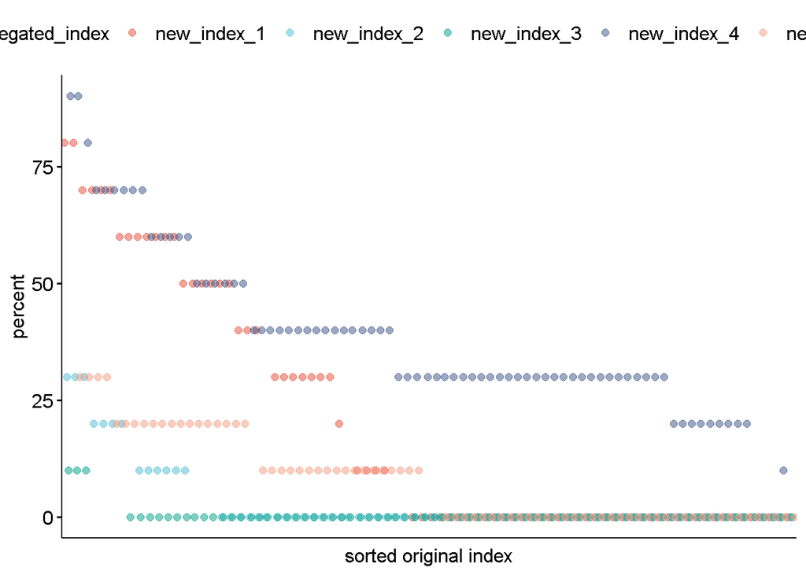

#### full table

The top n individual overlap between original and aggregaed indexes

| order | new_index_1.plant | new_index_1.value | new_index_2.plant | new_index_2.value | new_index_3.plant | new_index_3.value | new_index_4.plant | new_index_4.value | new_index_5.plant | new_index_5.value | index_15.plant | index_15.value | index_298.plant | index_298.value | index_17.plant | index_17.value | index_117.plant | index_117.value | index_126.plant | index_126.value | index_641.plant | index_641.value | index_215.plant | index_215.value | index_264.plant | index_264.value | index_463.plant | index_463.value | index_715.plant | … |
| --- | --- | --- | --- | --- | --- | --- | --- | --- | --- | --- | --- | --- | --- | --- | --- | --- | --- | --- | --- | --- | --- | --- | --- | --- | --- | --- | --- | --- | --- | --- |
| 1 | 275 | 51.695 | 256 | 7.588 | 322 | 9.193 | 468 | 40.574 | 275 | 39.549 | 275 | 30.266 | 275 | 30.599 | 468 | 92.925 | 468 | 67.650 | 275 | 61.461 | 275 | 50.763 | 468 | 56.797 | 275 | 66.073 | 275 | 41.649 | 275 | … |
| 2 | 160 | 49.151 | 486 | 6.868 | 456 | 8.440 | 248 | 38.207 | 313 | 35.739 | 468 | 25.619 | 468 | 24.320 | 275 | 92.708 | 275 | 67.515 | 468 | 60.902 | 468 | 48.695 | 275 | 56.695 | 468 | 66.064 | 468 | 40.908 | 468 | … |
| 3 | 120 | 49.067 | 147 | 6.743 | 412 | 8.311 | 275 | 34.317 | 277 | 34.675 | 161 | 23.550 | 161 | 23.813 | 293 | 80.457 | 293 | 58.898 | 293 | 49.829 | 12 | 42.974 | 361 | 52.522 | 293 | 61.075 | 293 | 38.608 | 293 | … |
| 4 | 293 | 46.531 | 498 | 6.162 | 84 | 8.045 | 444 | 33.810 | 135 | 34.350 | 12 | 23.327 | 313 | 23.512 | 361 | 74.718 | 361 | 52.964 | 414 | 48.802 | 161 | 41.453 | 293 | 51.939 | 361 | 60.581 | 361 | 38.098 | 361 | … |
| 5 | 161 | 43.540 | 162 | 5.748 | 431 | 7.751 | 278 | 33.045 | 385 | 32.995 | 385 | 22.688 | 385 | 23.423 | 161 | 73.308 | 414 | 52.758 | 12 | 48.341 | 293 | 40.936 | 120 | 48.884 | 120 | 56.237 | 120 | 35.952 | 161 | … |
| 6 | 416 | 42.749 | 153 | 5.488 | 499 | 7.389 | 414 | 32.625 | 8 | 31.182 | 313 | 22.333 | 120 | 23.034 | 12 | 73.190 | 161 | 52.471 | 248 | 48.164 | 469 | 40.830 | 469 | 46.839 | 161 | 54.611 | 161 | 34.539 | 469 | … |
| 7 | 385 | 42.603 | 109 | 5.446 | 44 | 7.381 | 111 | 31.819 | 133 | 29.512 | 153 | 21.449 | 293 | 22.819 | 414 | 72.075 | 12 | 51.692 | 161 | 46.675 | 361 | 40.376 | 161 | 46.715 | 469 | 53.847 | 469 | 33.531 | 120 | … |
| 8 | 361 | 42.295 | 117 | 5.231 | 66 | 7.036 | 153 | 31.302 | 500 | 29.200 | 293 | 21.448 | 160 | 22.199 | 120 | 70.776 | 385 | 51.476 | 385 | 45.761 | 120 | 39.742 | 12 | 44.741 | 12 | 52.047 | 12 | 32.224 | 451 | … |
| 9 | 451 | 40.287 | 170 | 5.229 | 276 | 6.832 | 487 | 31.077 | 394 | 28.891 | 248 | 21.432 | 12 | 21.355 | 385 | 70.090 | 120 | 50.881 | 487 | 44.555 | 248 | 37.620 | 385 | 42.663 | 385 | 50.300 | 385 | 31.880 | 385 | … |
| 10 | 394 | 39.004 | 397 | 5.143 | 262 | 6.668 | 12 | 30.883 | 356 | 28.532 | 160 | 20.622 | 162 | 20.441 | 469 | 69.777 | 487 | 50.378 | 120 | 43.611 | 414 | 37.319 | 451 | 42.514 | 451 | 49.967 | 451 | 31.609 | 12 | … |

## Variable pattern

The frequency of levels of a known variable in aggregated indexes. This can potentially provide insights into the possible reason behind the aggregation, if the frequency distribution of the known variable is uneven across aggregated indexes.

Below is the frequency/percent distribution of *zone* (variable) across *new_index_by_cluster* (aggregated or pre-defined grouping index).

### plot

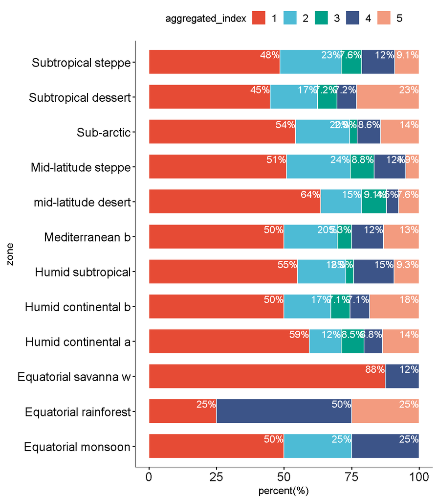

### full table

Distribution of zone across new_index_by_cluster

| aggregated_by | aggregated_index | n_Humid continental a | n_Humid continental b | n_Humid subtropical | n_Mediterranean b | n_mid-latitude desert | n_Mid-latitude steppe | n_Sub-arctic | n_Subtropical dessert | n_Subtropical steppe | n_Equatorial monsoon | n_Equatorial savanna w | n_Equatorial rainforest | percent_Humid continental a | percent_Humid continental b | percent_Humid subtropical | percent_Mediterranean b | percent_mid-latitude desert | percent_Mid-latitude steppe | percent_Sub-arctic | percent_Subtropical dessert | percent_Subtropical steppe | percent_Equatorial monsoon | percent_Equatorial savanna w | percent_Equatorial rainforest |
| --- | --- | --- | --- | --- | --- | --- | --- | --- | --- | --- | --- | --- | --- | --- | --- | --- | --- | --- | --- | --- | --- | --- | --- | --- | --- |
| sector | A | 2 | 10 | 15 | 8 | 6 | 10 | 2 | 6 | 5 | NA | NA | NA | 3.390 | 10.204 | 10.714 | 10.526 | 9.091 | 9.804 | 5.714 | 8.696 | 7.576 | NA | NA | NA |
| sector | B | 6 | 13 | 17 | 11 | 5 | 9 | 5 | 6 | 7 | NA | NA | NA | 10.169 | 13.265 | 12.143 | 14.474 | 7.576 | 8.824 | 14.286 | 8.696 | 10.606 | NA | NA | NA |
| sector | C | 6 | 10 | 11 | 5 | 6 | 9 | 5 | 3 | 3 | 1 | 2 | NA | 10.169 | 10.204 | 7.857 | 6.579 | 9.091 | 8.824 | 14.286 | 4.348 | 4.545 | 25 | 25.0 | NA |
| sector | D | 5 | 5 | 19 | 6 | 8 | 8 | NA | 6 | 5 | NA | 2 | NA | 8.475 | 5.102 | 13.571 | 7.895 | 12.121 | 7.843 | NA | 8.696 | 7.576 | NA | 25.0 | NA |
| sector | E | 4 | 8 | 13 | 10 | 6 | 12 | 3 | 6 | 11 | NA | 1 | 1 | 6.780 | 8.163 | 9.286 | 13.158 | 9.091 | 11.765 | 8.571 | 8.696 | 16.667 | NA | 12.5 | 25 |
| sector | F | 4 | 7 | 12 | 7 | 7 | 11 | 8 | 11 | 10 | 1 | 1 | 1 | 6.780 | 7.143 | 8.571 | 9.211 | 10.606 | 10.784 | 22.857 | 15.942 | 15.152 | 25 | 12.5 | 25 |
| sector | G | 11 | 10 | 11 | 7 | 5 | 7 | 2 | 2 | 4 | 1 | NA | 1 | 18.644 | 10.204 | 7.857 | 9.211 | 7.576 | 6.863 | 5.714 | 2.899 | 6.061 | 25 | NA | 25 |
| sector | H | 6 | 12 | 13 | 5 | 4 | 9 | 4 | 10 | 8 | NA | 1 | NA | 10.169 | 12.245 | 9.286 | 6.579 | 6.061 | 8.824 | 11.429 | 14.493 | 12.121 | NA | 12.5 | NA |
| sector | I | 10 | 11 | 13 | 4 | 9 | 10 | 3 | 6 | 3 | NA | NA | 1 | 16.949 | 11.224 | 9.286 | 5.263 | 13.636 | 9.804 | 8.571 | 8.696 | 4.545 | NA | NA | 25 |
| sector | J | 5 | 12 | 16 | 13 | 10 | 17 | 3 | 13 | 10 | 1 | 1 | NA | 8.475 | 12.245 | 11.429 | 17.105 | 15.152 | 16.667 | 8.571 | 18.841 | 15.152 | 25 | 12.5 | NA |
| new_index_by_cluster | 1 | 35 | 49 | 77 | 38 | 42 | 52 | 19 | 31 | 32 | 2 | 7 | 1 | 59.322 | 50.000 | 55.000 | 50.000 | 63.636 | 50.980 | 54.286 | 44.928 | 48.485 | 50 | 87.5 | 25 |
| new_index_by_cluster | 2 | 7 | 17 | 25 | 15 | 10 | 24 | 7 | 12 | 15 | 1 | NA | NA | 11.864 | 17.347 | 17.857 | 19.737 | 15.152 | 23.529 | 20.000 | 17.391 | 22.727 | 25 | NA | NA |
| new_index_by_cluster | 3 | 5 | 7 | 4 | 4 | 6 | 9 | 1 | 5 | 5 | NA | NA | NA | 8.475 | 7.143 | 2.857 | 5.263 | 9.091 | 8.824 | 2.857 | 7.246 | 7.576 | NA | NA | NA |
| new_index_by_cluster | 4 | 4 | 7 | 21 | 9 | 3 | 12 | 3 | 5 | 8 | 1 | 1 | 2 | 6.780 | 7.143 | 15.000 | 11.842 | 4.545 | 11.765 | 8.571 | 7.246 | 12.121 | 25 | 12.5 | 50 |
| new_index_by_cluster | 5 | 8 | 18 | 13 | 10 | 5 | 5 | 5 | 16 | 6 | NA | NA | 1 | 13.559 | 18.367 | 9.286 | 13.158 | 7.576 | 4.902 | 14.286 | 23.188 | 9.091 | NA | NA | 25 |

## Index weight pattern

The weight of each aggregated index as the sum of the weights of its corresponding original indexes of the same cluster. This can show which aggregated index was assigned the most or the least weight, which is often related to the importance of the aggregated index.

Below is the distribution of *weight* (index weight) across *new_index_by_cluster* (aggregated or pre-defined grouping index).

### plot

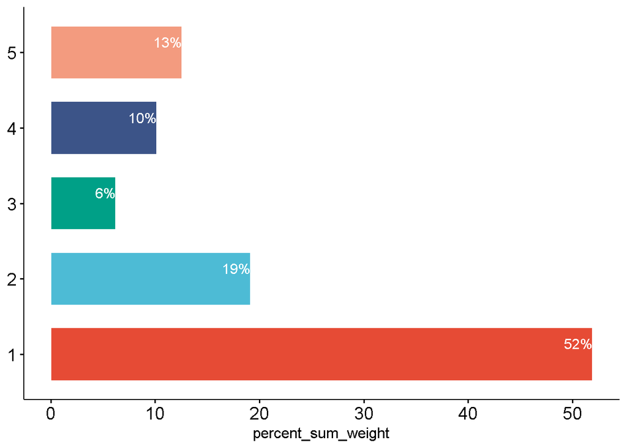

### full table

Distribution of weight across new_index_by_cluster

| aggregated_by | aggregated_index | sum_weight | percent_sum_weight |
| --- | --- | --- | --- |
| sector | A | 2822.309 | 8.855 |
| sector | B | 2962.438 | 9.295 |
| sector | C | 4072.100 | 12.776 |
| sector | D | 1041.033 | 3.266 |
| sector | E | 3980.060 | 12.487 |
| sector | F | 6006.104 | 18.844 |
| sector | G | 3570.286 | 11.202 |
| sector | H | 1961.083 | 6.153 |
| sector | I | 2479.552 | 7.780 |
| sector | J | 2977.471 | 9.342 |
| new_index_by_cluster | 1 | 16541.728 | 51.900 |
| new_index_by_cluster | 2 | 6097.897 | 19.132 |
| new_index_by_cluster | 3 | 1988.598 | 6.239 |
| new_index_by_cluster | 4 | 3235.302 | 10.151 |
| new_index_by_cluster | 5 | 4008.910 | 12.578 |